# brandfolder

David D.

2019-01-02

# why brandfolder?

## brandfolder checks all the boxes

- business model = subscription
- technology = SaaS
- total addressable market = anyone with a brand
- provides distinct solution to meaningful problem
  - *they come for asset management; they stay for the analytics*

# marketing

## person scoring

- in salesforce, leads & contacts are *people*
- who are these people? what role do they have in buying decision?
- what have they done? what is their campaign response history?

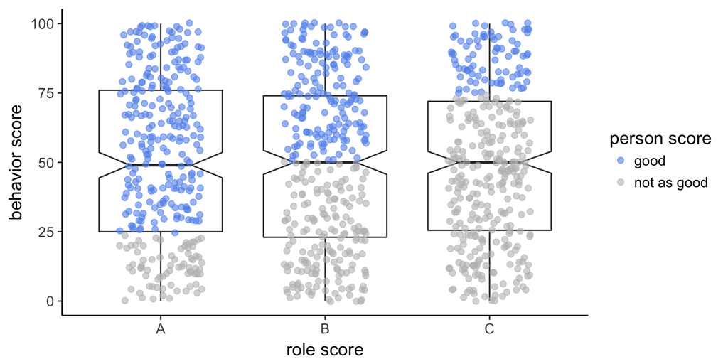

## account scoring

- combine people scores with account attributes
- can grade accounts by industry, size, technology, age…

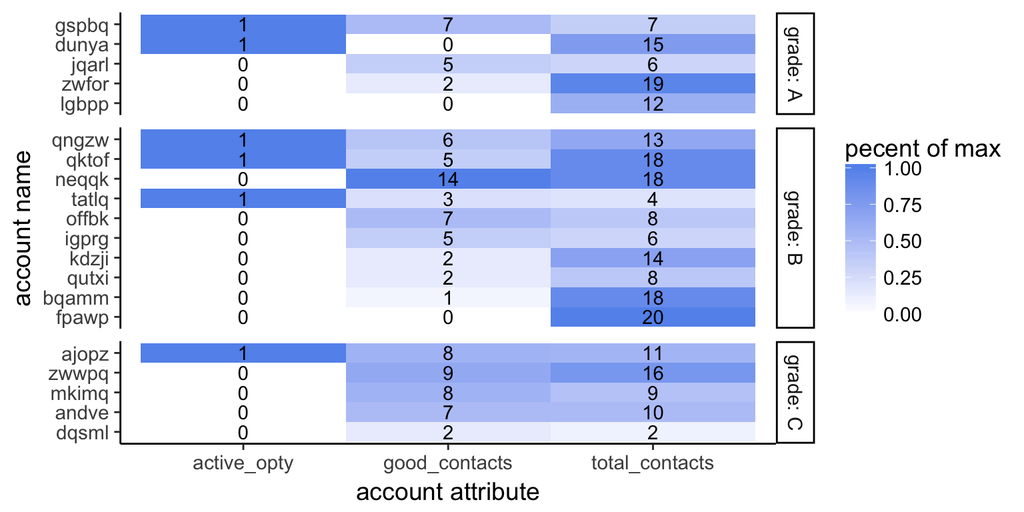

## which events to invest in

- each event requires an investment
- each event should yield a return
  - brand awareness
  - lead acquisition
  - nurture

## evaluating events

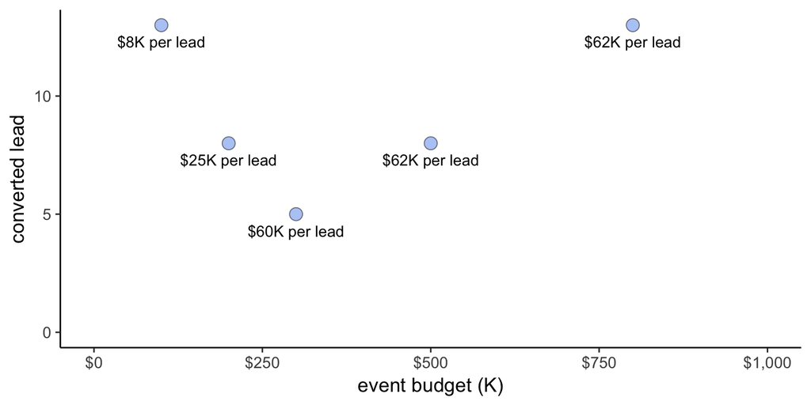

## optimizing marketing investments

- mind the lag
  - today’s investments may not yield bookings for months, years
- milestones to measure
  - how did we acquire the person record?
  - what was first thing they responded to?
  - what did they respond to before the deal created?
  - what did they respond to after created but before won?

# sales

## territory and industry pitfalls to avoid

- segmentation based on attributes that are not locked down
- territories that do not account for account families
- incoherent industry designations

## land, retain, and expand measures

- find attributes associated with churn risk: size? industry? usage?
- timing and kind of expansion
  - at renewal?
  - more seats or add products?
- plot cumulative year-over-year for seasonally adjusted compares

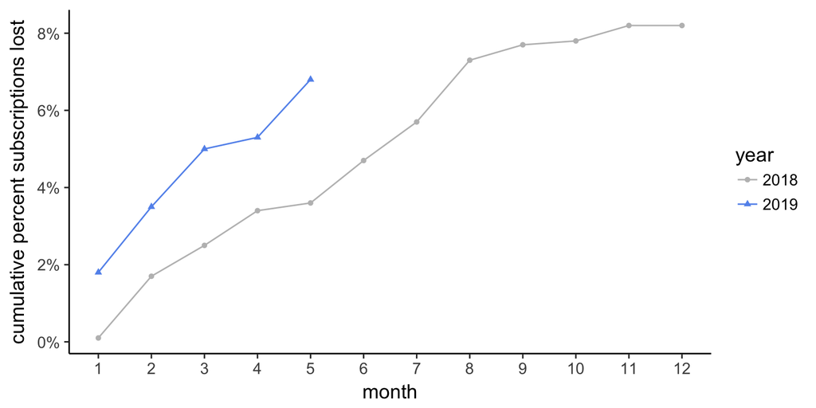

## account taxonomies

## pie charts?

- rank segments most to least
- where would error bars go?
- which grew the most?

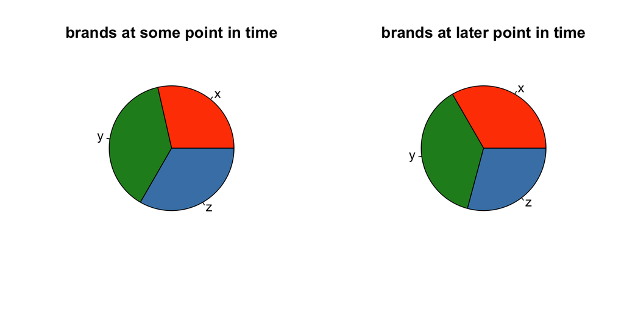

## same data as before

- rank segments most to least
- where would error bars go?
- how are these trending?

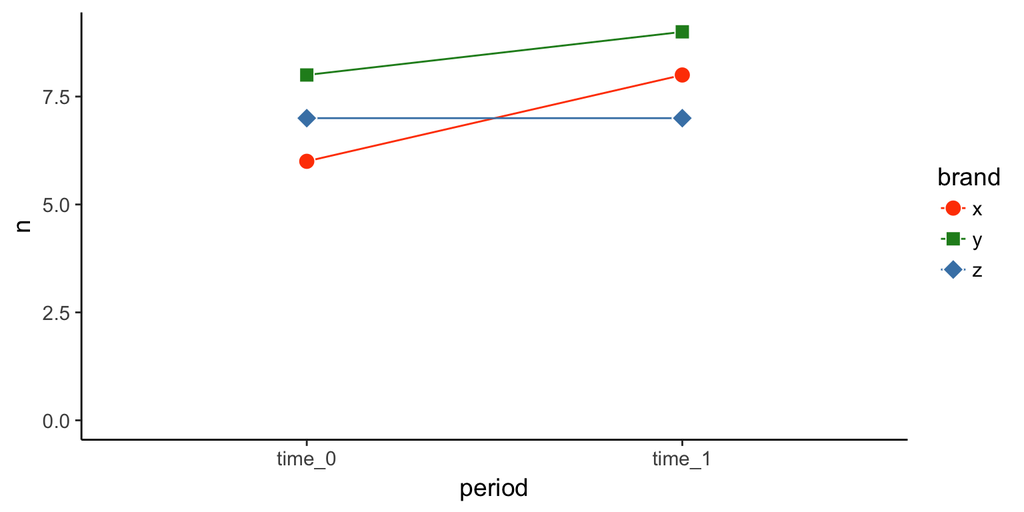

# end

## when not doing stuff like this

- family of 4 that likes to hike and camp
- run and bike
- do stuff like this
  - tried out `revealjs` markdown for this presentation